# Untitled

Yujia Gu

2022/3/10

##Introduction

###Background

Population aging has been a worldwide topic in recent years. As reported by World Health Organization(WHO) in Oct. 2021, by 2030, 1 in 6 people in the world will be aged 60 years or over. At the same time, every person should have the opportunity to live a long and healthy life. Therefore, healthy aging becomes a vital problem in our society. As one of the opposites to health, diseases, especially non-communicable diseases(NCDs) such as heart disease, cancer and diabetes, contribute a lot to the loss of health and life. Many risk factors have been found that have a relationship with non-communicable disease, such as unhealthy diets, physical inactivity, exposure to tobacco smoke or the harmful use of alcohol. ###Our Aims

1. Try to find causal relationships between risk factors and some specific noncommunicable diseases during the ageing process.
2. Find some of the most correlated risk factors to the noncommunicable diseases during the ageing process.

##Data Information

###Data Source Data was collected by several hospitals using questionaires and fitness tests. ###Data Preprocessing The following packages will be used in this project:

```r
library(dplyr)
library(tidyverse)
library(rlang)
library(ggplot2)
library(labelled)
library(stringr)
library(psych)
library(reshape2)
source("functions.R")
```

The dataset is equipped with two another files, which explain the questions and corresponding answers. We load all these files.

```r
BJdata <- readRDS("BJ_data.RDS")
question <- readRDS("question.RDS")
answer <- readRDS("answer.RDS")
```

A first view of the dataset:

```r
dim(BJdata)
```

```
## [1] 17417   422
```

```r
head(BJdata)
```

```
## # A tibble: 6 x 422
##   ID     ID0      ID1    ID2 ID3.A ID3.B ID3.C ID5       ID6     A2     A3    A4
##   <chr>  <chr> <int+> <int+> <chr> <chr> <chr> <chr> <int+l> <int+> <int+> <dbl>
## 1 393dd~ 甘肃~ 1 [是] 2 [否] 甘肃  兰州  城关  17-~  1 [城市社~ 1 [男] 1 [汉]    41
## 2 86e57~ 甘肃~ 1 [是] 2 [否] 甘肃  兰州  城关  23-~  1 [城市社~ 1 [男] 1 [汉]    70
## 3 3e862~ 甘肃~ 1 [是] 2 [否] 甘肃  兰州  城关  26-~  1 [城市社~ 2 [女] 1 [汉]    69
## 4 dfcbd~ 甘肃~ 1 [是] 2 [否] 甘肃  兰州  城关~ 20-~  1 [城市社~ 2 [女] 1 [汉]    67
## 5 245b2~ 甘肃~ 1 [是] 1 [是] 甘肃  兰州  城关  21-~  1 [城市社~ 1 [男] 1 [汉]    71
## 6 b32f5~ 甘肃~ 1 [是] 2 [否] 甘肃  兰州  城关  27-~  1 [城市社~ 2 [女] 1 [汉]    71
## # ... with 410 more variables: A5 <int+lbl>, A6 <int+lbl>, A7 <int+lbl>,
## #   A8 <int+lbl>, A8.1 <int+lbl>, A8.2 <int+lbl>, B1 <int>, B10.A <chr>,
## #   B10.B <dbl>, B11 <int+lbl>, B12 <int+lbl>, B13 <int+lbl>, B13.1 <chr>,
## #   B13.1.A <dbl>, B13.1.B <dbl>, B13.2 <chr>, B13.2.A <dbl>, B13.2.B <dbl>,
## #   B13.3 <chr>, B13.3.A <dbl>, B13.3.B <dbl>, B13.4 <chr>, B13.4.A <dbl>,
## #   B13.4.B <dbl>, B13.5 <chr>, B13.5.A <dbl>, B13.5.B <dbl>, B14 <int+lbl>,
## #   B15.1 <int+lbl>, B15.1.A <dbl>, B15.1.B <dbl>, B15.1.C <dbl>, ...
```

```r
head(question)
```

```
## # A tibble: 6 x 4
##   question_id colname        meaning            type
##   <chr>       <chr>          <chr>              <chr>
## 1 A2          性别           性别               choice
## 2 A3          民族           民族               choice
## 3 A4          年龄（岁）     年龄               double
## 4 A5          最高教育       完成的最高教育     choice
## 5 A6          婚姻状况       婚姻状况           choice
## 6 A7          现在的工作状况 您现在的工作状况？ choice
```

```r
answer%>%filter(startsWith(question_id,"A"))%>%head(9)
```

```
## # A tibble: 9 x 3
##   question_id value name
##   <chr>       <chr> <chr>
## 1 A2          1     男
## 2 A2          2     女
## 3 A3          1     汉
## 4 A3          2     蒙
## 5 A3          3     回
## 6 A3          4     藏
## 7 A3          5     其他
## 8 A5          1     文盲
## 9 A5          2     小学
```

We pick several risk factors and all 18 diseases as the variables and do the preprocessing. At the same time, to analysis the aging pattern, we devide age from 25 to 89 into 13 groups, with range of 4 in each groups, such as 25-29,30-34.

```r
data <- data_preprocess(BJdata,question,answer)
A <- cut_by_list(data,"Age",breaks = seq(25,85,by=5),lower = 25,upper = 90)
data <- data %>% mutate(AgeFactor=A$Age) %>% drop_na(AgeFactor,Gender,NoAlcohol,NoSmoking)

str(data)
```

```
## tibble [15,488 x 26] (S3: tbl_df/tbl/data.frame)
##  $ Gender                                : chr [1:15488] "男" "男" "女" "女" ...
##  $ Age                                   : num [1:15488] 41 70 69 67 71 71 81 73 66 67 ...
##   ..- attr(*, "label")= chr "年龄（岁）"
##  $ RegLife                               : num [1:15488] 1 1 1 0 1 1 1 1 1 1 ...
##  $ Exercise                              : num [1:15488] 1 1 1 1 1 1 1 1 1 1 ...
##  $ NoAlcohol                             : num [1:15488] 0 1 1 1 1 1 1 1 1 1 ...
##  $ NoSmoking                             : num [1:15488] 0 1 1 0 0 1 1 1 0 1 ...
##  $ BMI                                   : num [1:15488] 24.4 27.7 27.4 19.3 17.8 ...
##   ..- attr(*, "label")= chr "体质指数"
##  $ 高血压                                : num [1:15488] 0 0 0 0 0 0 0 0 0 0 ...
##  $ 颈腰椎疾病                            : num [1:15488] 0 1 0 0 0 0 0 1 0 0 ...
##  $ 胃肠疾病                              : num [1:15488] 0 0 0 0 0 0 0 0 0 0 ...
##  $ 帕金森氏病                            : num [1:15488] 0 0 0 0 0 0 0 0 0 0 ...
##  $ 跌倒                                  : num [1:15488] 0 0 0 0 0 0 0 0 0 0 ...
##  $ 关节炎                                : num [1:15488] 0 0 0 0 0 0 0 1 0 0 ...
##  $ 痴呆                                  : num [1:15488] 0 0 0 0 0 0 0 0 0 0 ...
##  $ 肢体残疾                              : num [1:15488] 0 0 0 0 0 0 0 0 0 0 ...
##  $ 代谢紊乱（血糖、血脂、血尿酸水平升高）: num [1:15488] 0 0 0 0 0 1 0 0 0 0 ...
##  $ 其他                                  : num [1:15488] 0 0 0 0 0 0 0 0 0 0 ...
##  $ 糖尿病                                : num [1:15488] 0 0 0 0 0 0 0 0 0 0 ...
##  $ 心脏病                                : num [1:15488] 0 0 0 0 0 0 0 0 0 0 ...
##  $ 中风及脑血管疾病                      : num [1:15488] 0 1 0 0 1 0 0 0 0 0 ...
##  $ 支气管炎，肺气肿，哮喘或肺炎          : num [1:15488] 0 0 0 0 0 0 0 0 0 0 ...
##  $ 肺结核                                : num [1:15488] 0 0 0 0 0 0 0 0 0 0 ...
##  $ 白内障                                : num [1:15488] 0 0 0 0 1 0 0 0 0 0 ...
##  $ 慢性肾炎                              : num [1:15488] 0 0 0 0 0 0 0 0 0 0 ...
##  $ 癌症                                  : num [1:15488] 0 0 0 0 0 0 0 0 0 0 ...
##  $ AgeFactor                             : Factor w/ 13 levels "25-29","30-34",..: 4 10 9 9 10 10 12 10 9 9 ...
```

Note:

1. All those data are self-reported, which may have bias.
2. We compress Alcohol and Smoking into 0-1 variables by 0 indicates drinking/smoking now.

```r
question%>%filter(question_id=="B17" | question_id=="B18")
```

```
## # A tibble: 2 x 4
##   question_id colname  meaning      type
##   <chr>       <chr>    <chr>        <chr>
## 1 B17         是否喝酒 您是否喝酒？ choice
## 2 B18         是否吸烟 您是否吸烟？ choice
```

```r
answer%>%filter(question_id=="B17"| question_id=="B18")
```

```
## # A tibble: 7 x 3
##   question_id value name
##   <chr>       <chr> <chr>
## 1 B17         1     不喝酒
## 2 B17         2     现在经常喝酒
## 3 B17         3     过去经常喝，已戒
## 4 B18         1     从不吸烟
## 5 B18         2     现在吸烟(>5支/天)
## 6 B18         3     偶尔吸烟
## 7 B18         4     过去吸，已戒(不吸烟1个月以上)
```

##Explortary Data Analysis

###Single Index Analysis

First we show the proportion of each risk factors with respect to gender.

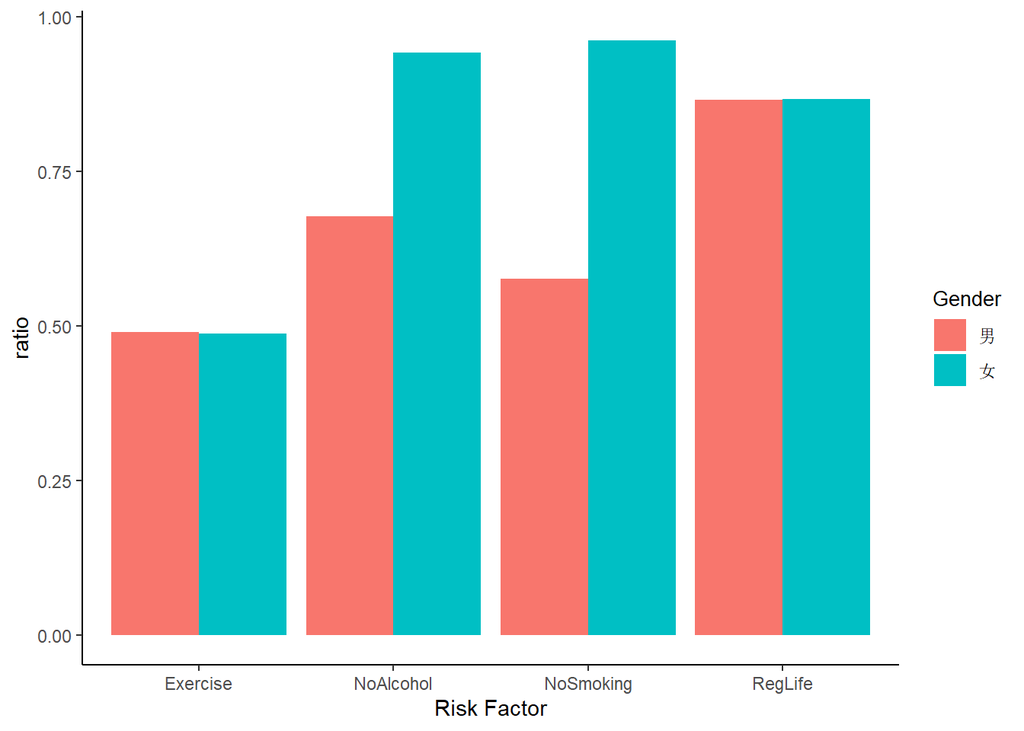

```r
ratio_bar_plot(data)
```

We draw line plots for each of the 0-1 risk factors, with the proportion of the factor in each age group and gender group.

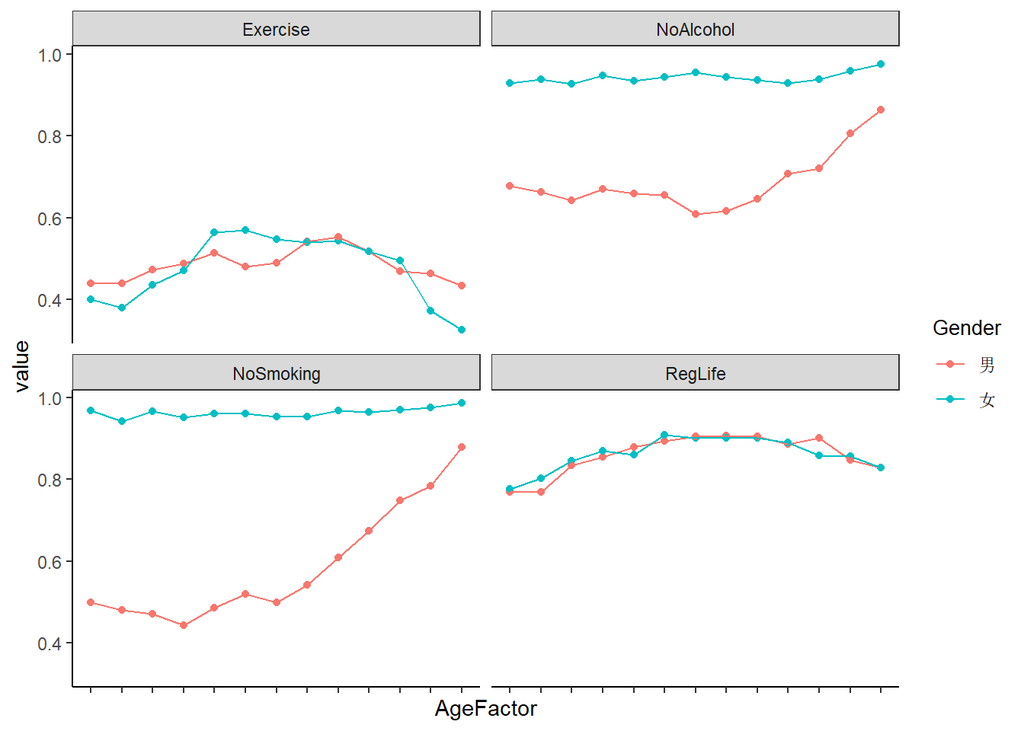

```r
loc=c(3,4,5,6)
ratio_line_plotTogether(data,"Gender",loc)
```

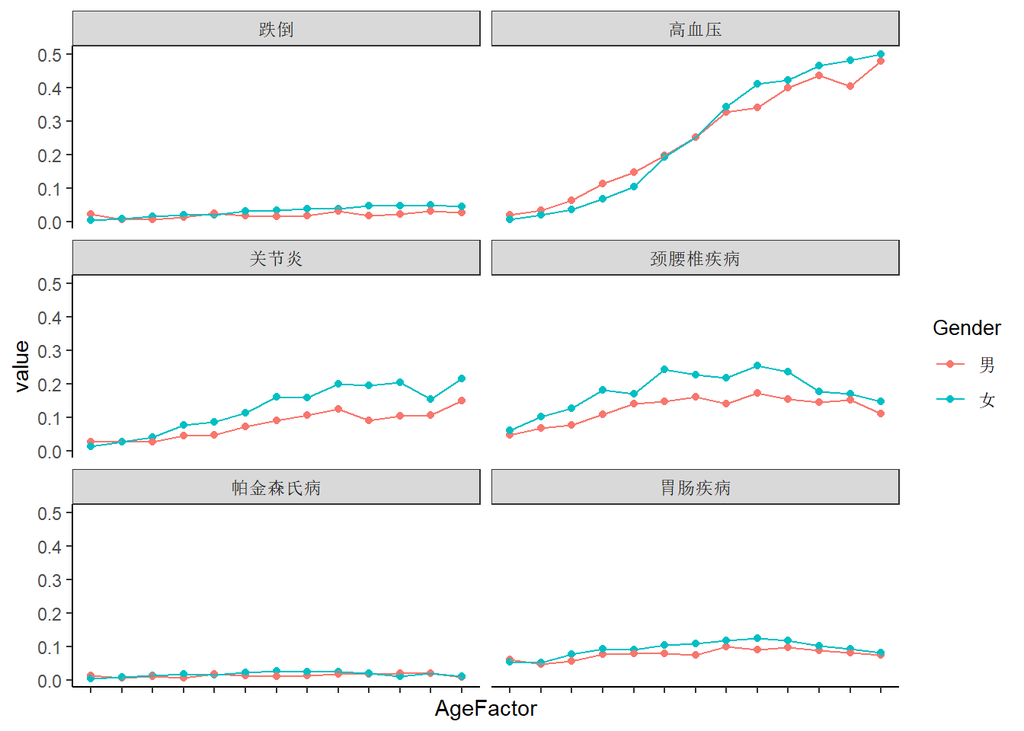

```r
loc=8:13
ratio_line_plotTogether(data,"Gender",loc)
```

###Interaction Analysis

####Ageing Trend We calculate the proportion of people who has healthy style of risk factors but has disease as well.

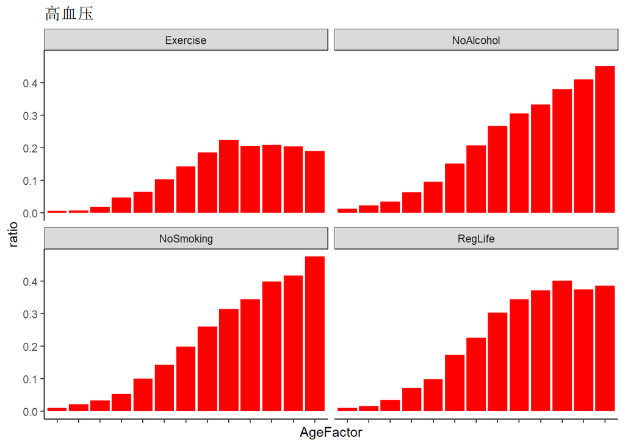

```r
ratio_bar_plotInter(data,"高血压")
```

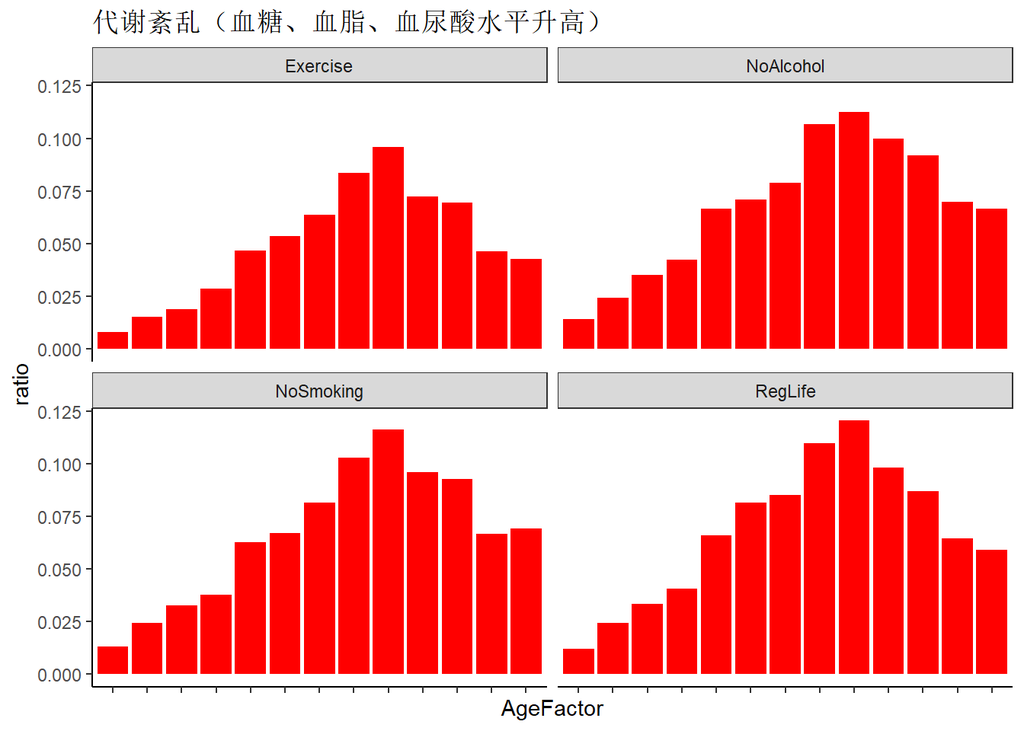

```r
ratio_bar_plotInter(data,"代谢紊乱（血糖、血脂、血尿酸水平升高）")
```

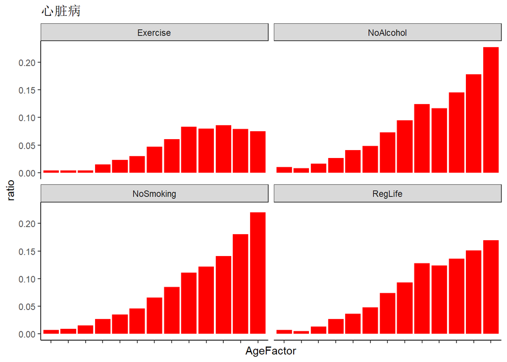

```r
ratio_bar_plotInter(data,"心脏病")
```

####Correlation Heatmap

To have a more straightforward view, we calculate the correlation between the risk factors and diseases in different age groups. Also, we calculate separately with gender as well. We use tetrachoric correlation to derive the correlation between two dichotomous variables.

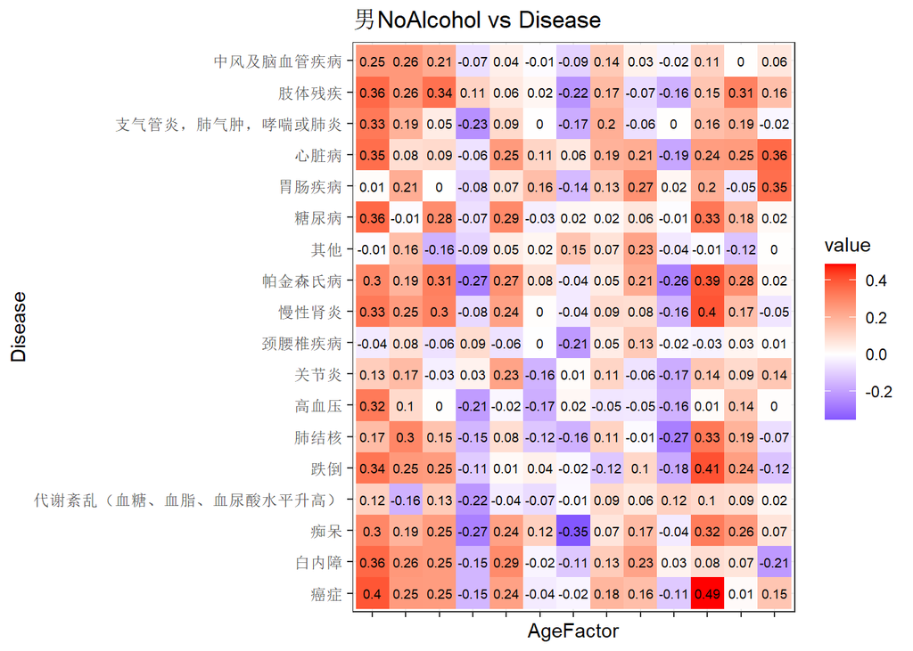

```r
cor_heatmap_spec(data,"男","NoAlcohol")
```

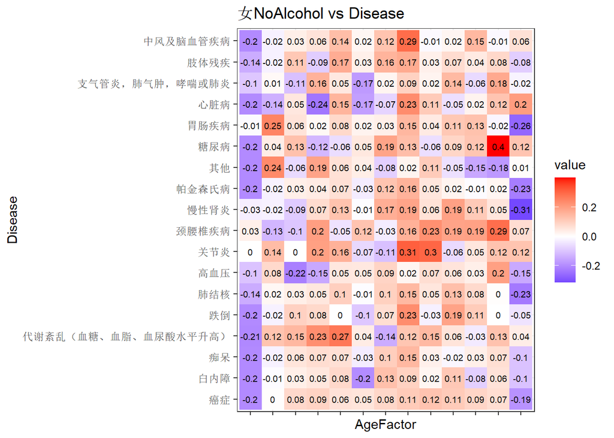

```r
cor_heatmap_spec(data,"女","NoAlcohol")
```

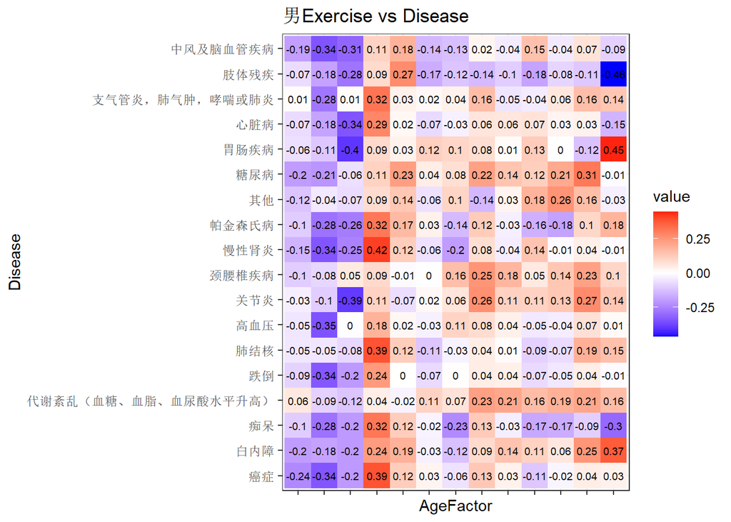

```r
cor_heatmap_spec(data,"男","Exercise")
```

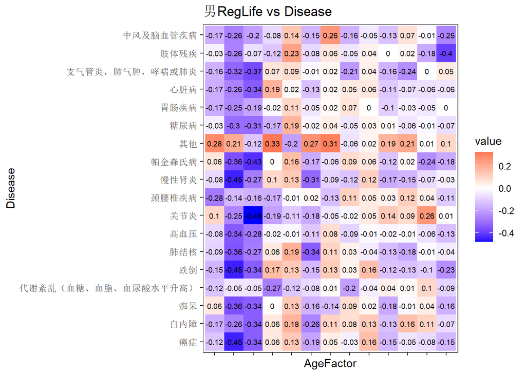

```r
cor_heatmap_spec(data,"男","RegLife")
```

Note:

1. The correlation heatmaps imply different relationship between some risk factors and diseases through the ageing process. Male and female may show different patterns as well.
2. A causal relationship through the ageing process may be of great intest. The exercise heatmap may lead to a causal chain as not doing exercise lead to disease and result in doing exercise afterwards.

####Simple Causal Analysis

A simple method to decide whether $X$ has influence on $Y$ is to compare the conditional distribution of $Y$ given different value of $X$(Pearl,2014). When $X$ and $Y$ are dichotomous variables, it can provide a clear view of the existence of causation under this structure.

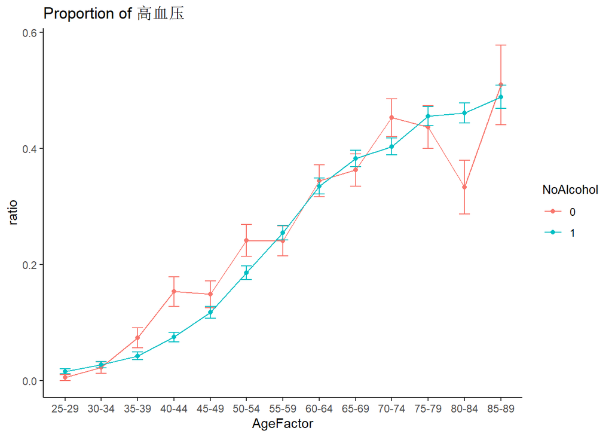

```r
ratio_line_plot(data,"NoAlcohol","高血压")
```

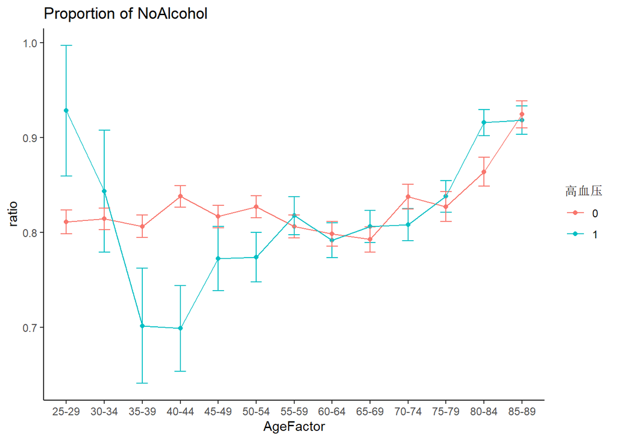

```r
ratio_line_plot(data,"高血压","NoAlcohol")
```

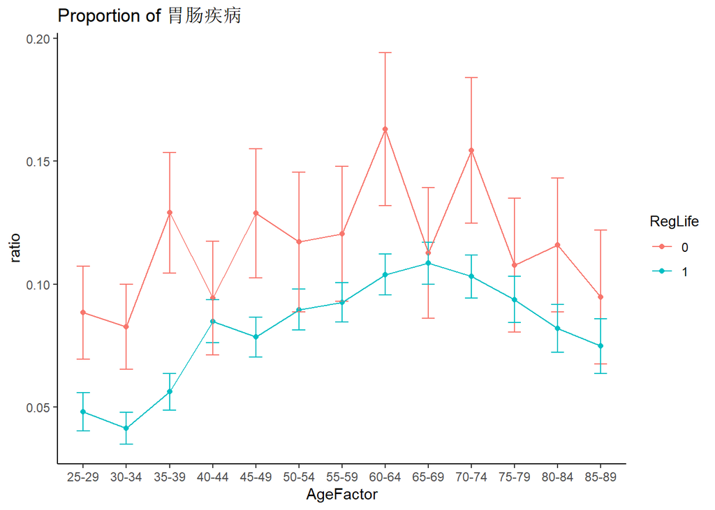

```r
ratio_line_plot(data,"RegLife","胃肠疾病")
```

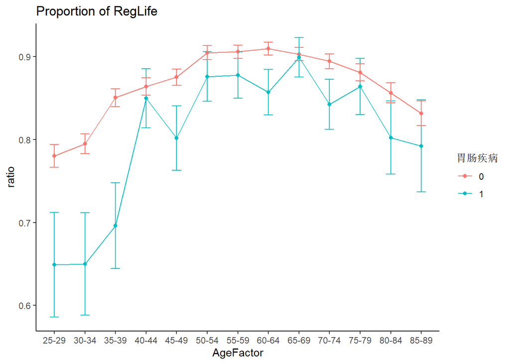

```r
ratio_line_plot(data,"胃肠疾病","RegLife")
```

##Future Work

1. Add more risk factors into consideration, such as dietary habits and metabolic indexes.
2. Construct causal graphic models for risk factors and diseases.

##Appendix

###Function Codes

```r
#data preprocessing

data_preprocess <- function(df,question,answer){
  data <- df %>% select(A2,A4,B12,B13,B17_new,B18_new,K2.2,starts_with("D1."))%>%
    filter(A4>=25 & A4<=89) %>%
    mutate(RegLife=2-B12,Exercise=B13-1,NoAlcohol=ifelse(B17_new==1,1,0),NoSmoking=ifelse(B18_new==1,1,0))%>%
    mutate(across(.cols = starts_with("D"),~ifelse(is.na(.x),0,1)))%>%
    unlabelled()
  nm_ls <- answer %>% filter(question_id == "A2") %>% mutate(value=as.numeric(value))
  data <- data %>% left_join(nm_ls,by=c("A2"="value")) %>% mutate(A2=name) %>%select(-c(question_id,name))

  colD_nm <- question %>%filter(startsWith(question_id,"D1."))%>% pull(colname)

  data <- data %>% rename(Gender=A2,Age=A4,BMI=K2.2)
  data <- data %>% rename_with(function(x){x<-colD_nm},.cols=starts_with("D"))
  data <- data %>% select(c(Gender,Age,RegLife,Exercise,NoAlcohol,NoSmoking,BMI,all_of(colD_nm))) %>%
    filter(!is.na(BMI) & !is.na(RegLife) & !is.na(Exercise)) %>%
    filter(RegLife %in% c(0,1) & Exercise %in% c(0,1))

  return(data)
}

cut_by_list <- function(data, name, breaks, lower = -Inf, upper = Inf) {
  if (name %in% colnames(data)) {
    breaks <- breaks[breaks < upper & breaks >= lower]
    if (length(breaks) > 0) {
      breaks <- sort(breaks)
      New <- purrr::reduce2(c(lower, breaks), c(breaks, upper), function(x, y, z) {
        label <- paste(y, "-", z-1, sep = "")
        x %>% mutate(Factor = ifelse((y <= value) & (value < z), label, Factor))
      }, .init = data %>% transmute(Factor = NA, value = .data[[name]]))
      data[[name]] <- (as.factor(pull(New, Factor)))
      data
    } else {
      stop("No point left")
    }
  } else {
    stop("No col find in dataset")
  }
}

#-------EDA bar plot---------

ratio_bar_plot<-function(data){
  data_new <- data %>% group_by(Gender) %>%
    mutate(NoAlcohol=sum(NoAlcohol)/n(), NoSmoking=sum(NoSmoking)/n(),
           RegLife=sum(RegLife)/n(), Exercise=sum(Exercise)/n())

  data_new <- data_new %>% select(all_of(c(1,3,4,5,6))) %>%
    pivot_longer(cols = all_of(c(2,3,4,5))) %>%unique

  ggplot(data_new,aes(x=name,y=value,group=Gender)) +
    geom_bar(aes(fill = Gender),stat = 'identity',position = 'dodge') +
    xlab("Risk Factor") +
    ylab("ratio") +
    theme_bw() +
    theme(axis.ticks.length = unit(0.1, "cm")) +
    theme(panel.grid = element_blank()) +
    theme(panel.border = element_blank()) +
    theme(axis.line = element_line(size = 0.5, colour = "black")) +
    theme(
      legend.title = element_text(size = 10, face = "plain", color = "black"),
      legend.background = element_blank()
      )
}

ratio_bar_plotInter <- function(data,Disease){
  data_new <- data%>% mutate(across(.cols=all_of(3:6),~ifelse(!!sym(Disease)==1 & .x==1,1,0)))
  data_new <- data_new%>%group_by(AgeFactor)%>%mutate(across(.cols=all_of(3:6),~sum(.x)/n())) %>%
    select(AgeFactor,all_of(3:6))%>%
    pivot_longer(cols = all_of(2:5))%>%
    unique

  ggplot(data_new,aes(x=AgeFactor,y=value))+
    geom_bar(fill="red",stat = 'identity',position="dodge")+
    ylab("ratio")+
    ggtitle(Disease)+
    theme_bw() +
    theme(axis.ticks.length = unit(0.1, "cm")) +
    theme(axis.text.x = element_blank())+
    theme(panel.grid = element_blank()) +
    theme(panel.border = element_blank()) +
    theme(axis.line = element_line(size = 0.5, colour = "black")) +
    theme(
      legend.title = element_text(size = 10, face = "plain", color = "black"),
      legend.background = element_blank()
    )+
    facet_wrap(~name)

}
#------EDA line plot-----
ratio_line_plotTogether<- function(data,gn,loc,nrow=NULL,ncol=2){
  data_new <- data %>% group_by(!!sym(gn),AgeFactor)%>%
    mutate(across(.cols=all_of(loc-1), ~sum(.x)/n()))
  data_new <- data_new %>% select(!!sym(gn),AgeFactor,all_of(loc)) %>%
    pivot_longer(cols = !c(1,2)) %>%unique

  data_new %>% ggplot(aes(x=AgeFactor,y=value,group=!!sym(gn)))+
    geom_point(aes(color=factor(!!sym(gn))))+
    geom_line(aes(color=factor(!!sym(gn))))+
    guides(color = guide_legend(title = gn)) +
    theme_bw() +
    theme(axis.ticks.length = unit(0.1, "cm")) +
    theme(axis.text.x = element_blank())+
    theme(panel.grid = element_blank()) +
    theme(panel.border = element_blank()) +
    theme(axis.line = element_line(size = 0.5, colour = "black")) +
    theme(
      legend.title = element_text(size = 10, face = "plain", color = "black"),
      legend.background = element_blank()
    )+
    facet_wrap(~name,nrow=nrow,ncol=ncol)

}


ratio_line_plot<- function(data,gn,varibale_name){
  data_new <- data %>% group_by(!!sym(gn),AgeFactor)%>%
    mutate(ratio=sum(!!sym(varibale_name))/n()) %>%
    mutate(ste=sqrt(ratio*(1-ratio)/n()))

  data_new <- data_new %>% select(AgeFactor,!!sym(gn),ratio,ste)

  data_new%>%ggplot(aes(x=AgeFactor,y=ratio,group=!!sym(gn),color=factor(!!sym(gn)))) +
    geom_point(aes(color=factor(!!sym(gn))))+
    geom_errorbar(
                  aes(ymin = ratio - ste,
                      ymax = ratio + ste), width = 0.3,
                  size = 0.5) +
    geom_line(aes(color=factor(!!sym(gn))))+
    ggtitle(paste0("Proportion of ",varibale_name))+
    guides(color = guide_legend(title = gn)) +
    theme_bw() +
    theme(axis.ticks.length = unit(0.1, "cm")) +
    theme(panel.grid = element_blank()) +
    theme(panel.border = element_blank()) +
    theme(axis.line = element_line(size = 0.5, colour = "black")) +
    theme(
      legend.title = element_text(size = 10, face = "plain", color = "black"),
      legend.background = element_blank()
    )
}

ratio_line_plotGender <- function(data,gn,varibale_name,Gd){
  data_new <- data %>% group_by(Gender,!!sym(gn),AgeFactor)%>% mutate(ratio=sum(!!sym(varibale_name))/n())
  data_newG <- data_new %>% filter(Gender==Gd)
  data_newG%>%ggplot(aes(x=AgeFactor,y=ratio,group=!!sym(gn))) +
    geom_point(aes(color=!!sym(gn)))+
    geom_line(aes(color=!!sym(gn))) +
    ggtitle(Gd)
}
#------heatmap plot-------
cor_heatmap <- function(corMatrix){
  cor_matrix <- data.frame(corMatrix)

  b <- cor_matrix %>% pivot_longer(everything(),names_to = "var1",
                                   values_to = "value")
  b <- b %>% mutate(var2=str_extract(rownames(b),"\\w+"))

  ggplot(b,aes(x=var2,y=var1,fill=abs(value)))+
    geom_tile()+
    geom_text(aes(label=round(value,2)),size=2.5)+
    scale_fill_gradient(low="white",high="red")
}

cor_heatmap_spec<-function(data,Gd,variable){
  Age_ls <- data %>% arrange(Age) %>% select(AgeFactor)%>%unique %>%
    pull(AgeFactor) %>%as.character
  Disease_ls <- colnames(data[8:25])
  variable_matrix <- matrix(NA,18,13)
  for(i in 1:length(Age_ls)){
    corMatrix <- data%>% filter(Gender==Gd,AgeFactor==Age_ls[i])%>%
      select(!!sym(variable),all_of(8:25)) %>%
      mixedCor(d=1:19)
    variable_matrix[,i]<- corMatrix[[1]][2:19,1]
  }

  variable_matrix <- data.frame(variable_matrix)
  colnames(variable_matrix)<- Age_ls
  variable_matrix <- variable_matrix %>%mutate(var2=Disease_ls)

  b <- melt(variable_matrix,id="var2",variable.name = "var1",value.name = "value")

  ggplot(b,aes(x=var1,y=var2,fill=value))+
    geom_tile()+
    geom_text(aes(label=round(value,2)),size=2.5)+
    scale_fill_gradient2(low="blue",mid="white",high="red",midpoint = 0)+
    xlab("AgeFactor")+
    ylab("Disease")+
    ggtitle(paste0(Gd,variable," vs Disease"))+
    theme_bw()+
    theme(axis.text.x = element_blank())
}
```